# Preliminary_results: ARDS on young population in FRBDX

# 5 Treatment and outcomes : Comparison ARDS 18-49 versus ARDS >50

## 5.1 ICD10/9

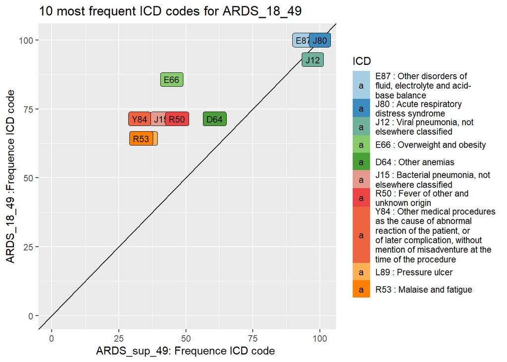

For the 10 most frequent ICD-10/9 codes for the group ARDS 18-49, in x coordinate the frequency(%) of those code for the group ARDS sup 49 and in y coordinate the frequency(%) of those code for the group ARDS 18-49

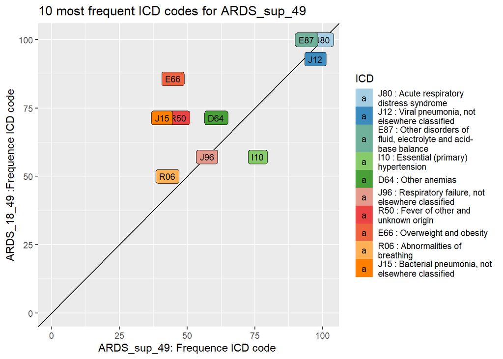

For the 10 most frequent ICD-10 codes for the group ARDS sup 49, in x coordinate the frequency(%) of those code for the group ARDS sup 49 and in y coordinate the frequency(%)of those code for the group ARDS 18-49

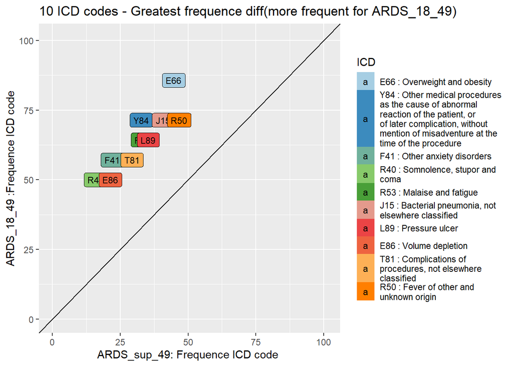

For the 10 ICD-10/9 with the greatest difference in term of frequency between ARDS sup 49 and ARDS 18-49 groups codes for the group ARDS sup 49 and more frequent for the ARDS 18-49 group , in x coordinate the frequency(%) of those code for the group ARDS sup 49 and in y coordinate the frequency(%)of those code for the group ARDS 18-49

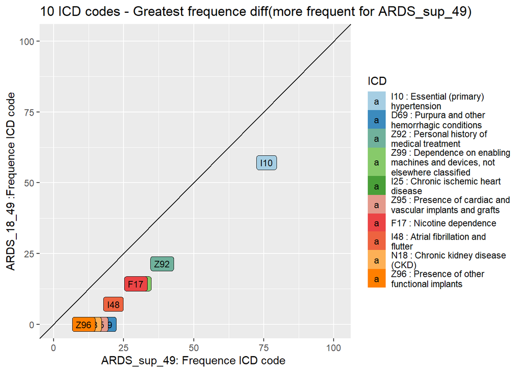

For the 10 ICD-10 with the greatest difference in term of frequency between ARDS sup 49 and ARDS 18-49 groups codes for the group ARDS sup 49 and more frequent for the ARDS sup 49 group , in x coordinate the frequency(%) of those code for the group ARDS sup 49 and in y coordinate the frequency(%)of those code for the group ARDS 18-49

**After hospitalization due to covid: Percentage of patients with ICD10/9**

| ICD | ICD_title | ARDS_18_49 | ARDS_sup_49 |
| --- | --- | --- | --- |
| A04 | Other bacterial intestinal infections |  | 1.3 |
| A08 | Viral and other specified intestinal infections |  | 0.7 |
| A09 | Infectious gastroenteritis and colitis, unspecified | 35.7 | 16.7 |
| A40 | Streptococcal sepsis |  | 0.7 |
| A41 | Other sepsis | 21.4 | 16.7 |
| A49 | Bacterial infection of unspecified site |  | 0.7 |
| A97 |  |  | 0.7 |
| B00 | Herpesviral [herpes simplex] infections | 7.1 | 4.7 |
| B02 | Zoster [herpes zoster] | 7.1 |  |
| B25 | Cytomegaloviral disease |  | 0.7 |

[output cut: 433 more lines]

## 5.2 Medication

**Number of patient with at least one medication per medication classes**

| concept_code | ARDS_18_49 | ARDS_sup_49 |
| --- | --- | --- |
| ACEI | 1 | 15 |
| ARB | 3 | 21 |
| COAGB | 11 | 110 |
| DIURETIC | 1 | 13 |
| COAGA |  | 5 |
| COVIDVIRAL |  | 2 |
| HCQ |  | 2 |
| ILI |  | 3 |
| SIANES |  | 6 |

## 5.3 Procedure

**Number of patient with at least one procedure per medication procedure**

| concept_code | title | ARDS_18_49 | ARDS_sup_49 |
| --- | --- | --- | --- |
| 0BH17EZ | Insertion of Endotracheal Airway into Trachea, Via Opening | 5 | 51 |
| 5A09357 | Assistance with Respiratory Ventilation, Less than 24 Consecutive Hours, Continuous Positive Airway Pressure | 8 | 70 |
| 5A0935B | Assistance with Respiratory Ventilation, Less than 24 Consecutive Hours, Intermittent Negative Airway Pressure | 11 | 95 |
| 5A0935Z | Assistance with Respiratory Ventilation, Less than 24 Consecutive Hours |  | 13 |

## 5.4 Outcomes

**Death, death before 28/90days, out the hospital at 28/90 days**

| GROUP | # patients | # dead | # dead before 28 days | # dead before 90 days | # discharged before 28 days | # discharged before 90 days |
| --- | --- | --- | --- | --- | --- | --- |
| ARDS_18_49 | 14 | 0 | 0 | 0 | 5 | 13 |
| ARDS_sup_49 | 150 | 37 | 30 | 36 | 102 | 138 |

**Patients with and without rehopitalization after Covid admission**

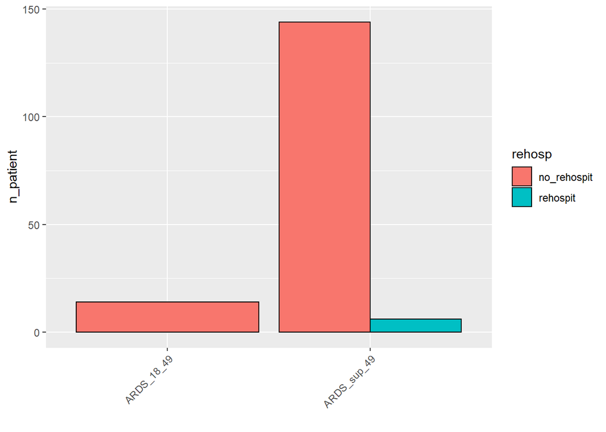

## 5.5 LAB - Evolution between ARDS_18_49 and ARDS_sup_49 for the two first weeks

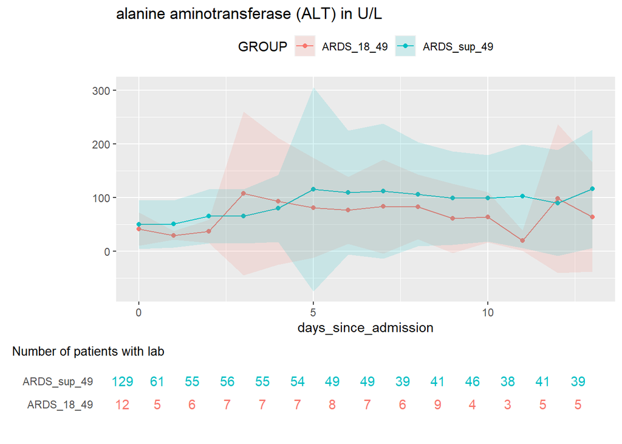

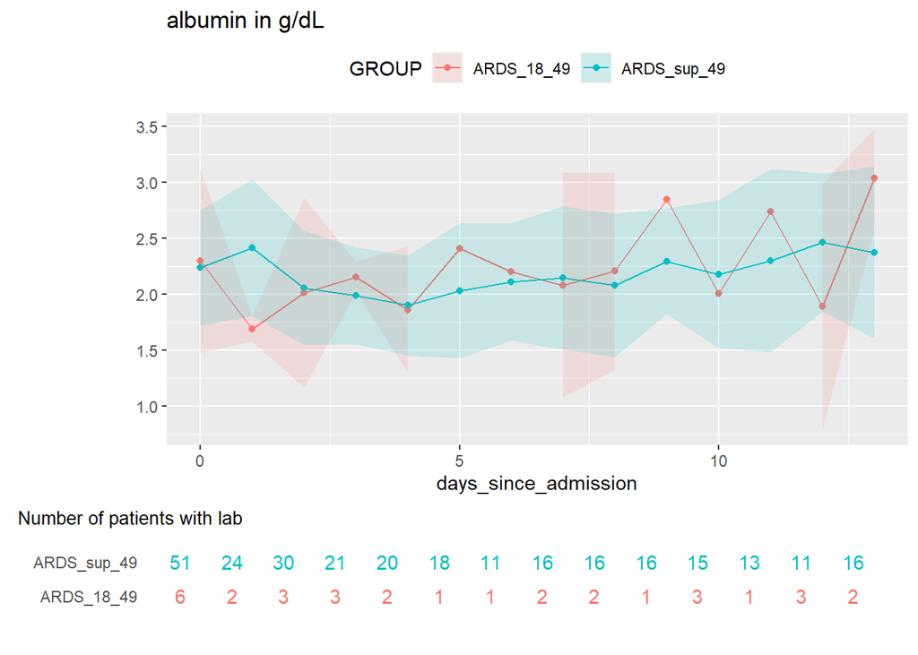

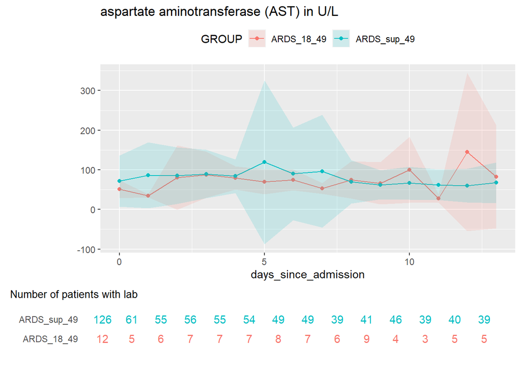

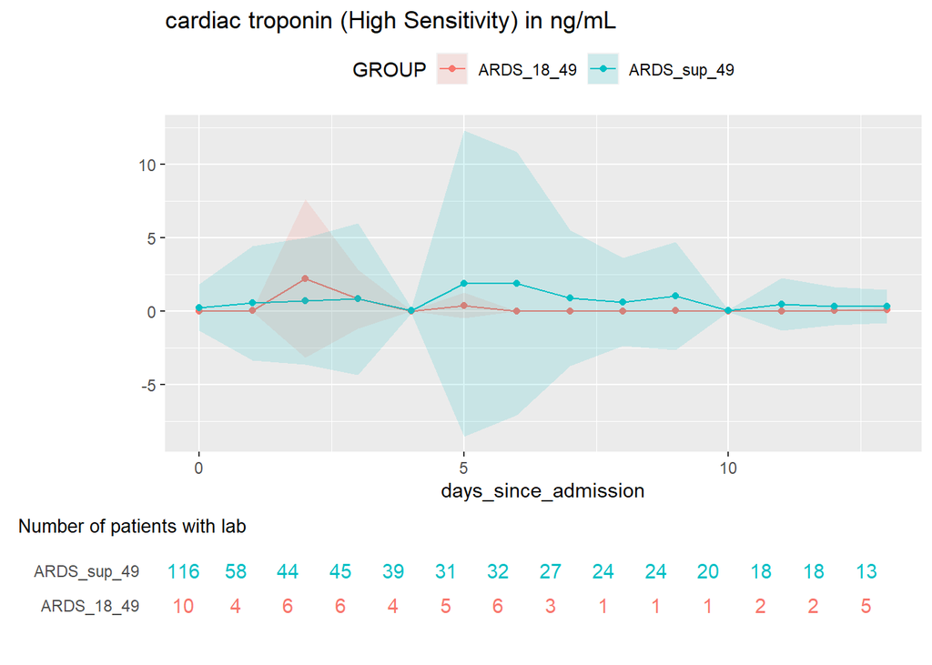

[figure not shown]

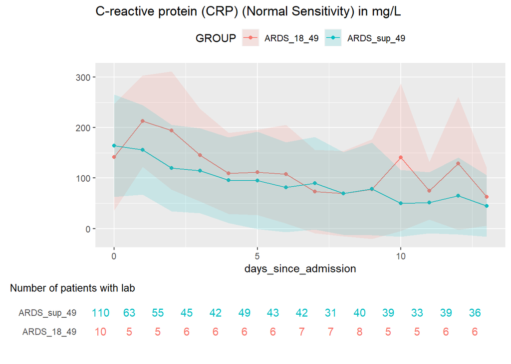

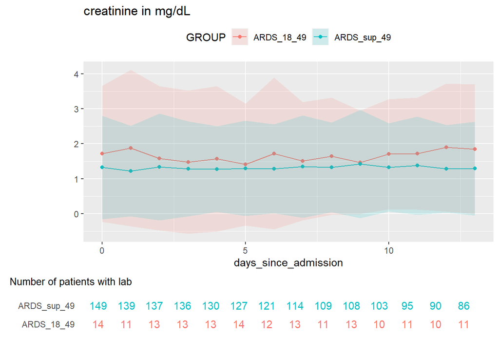

[figure not shown]

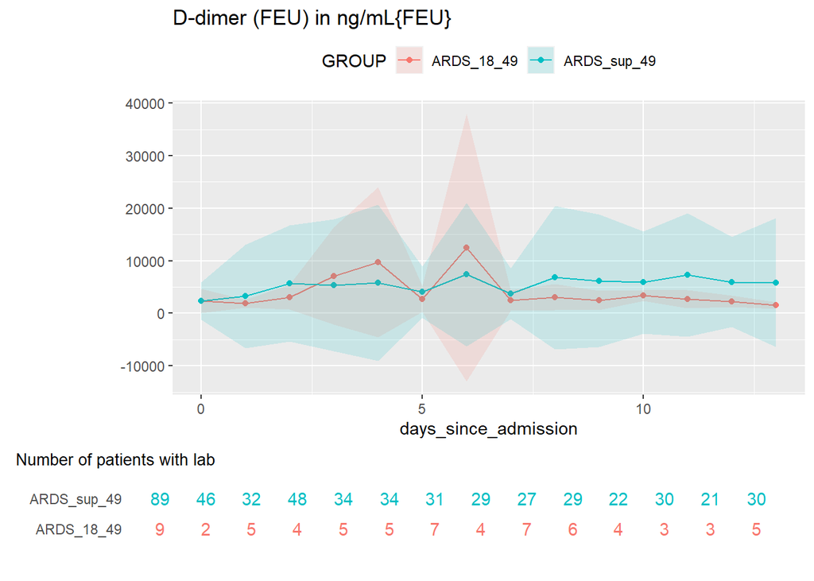

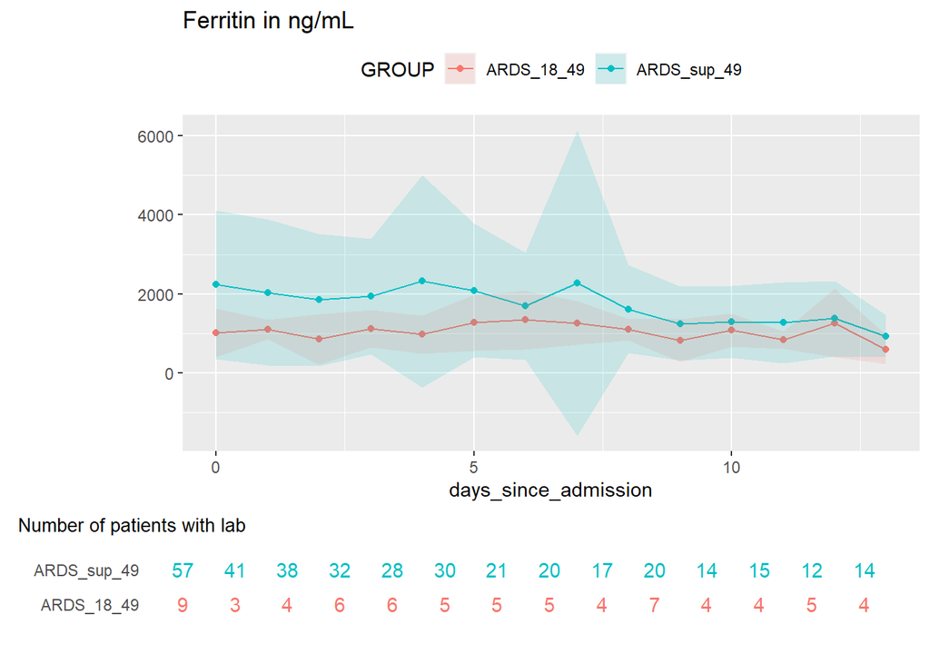

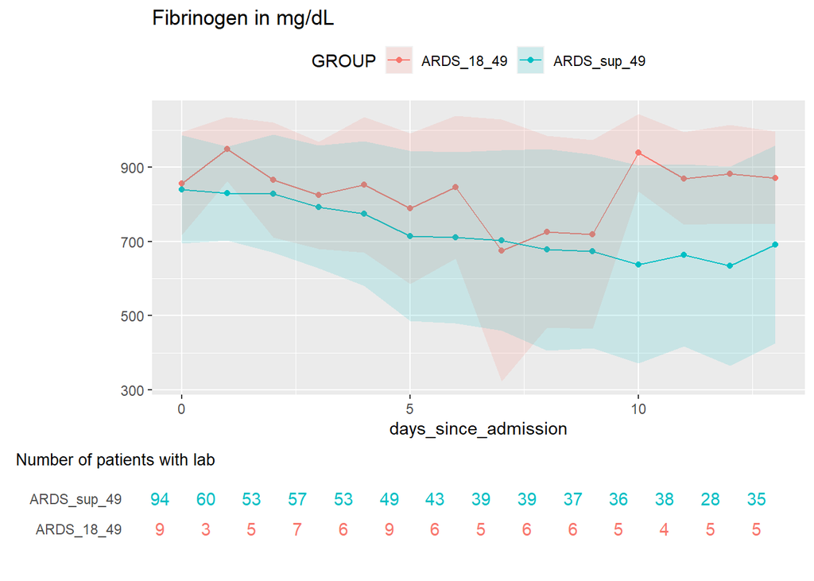

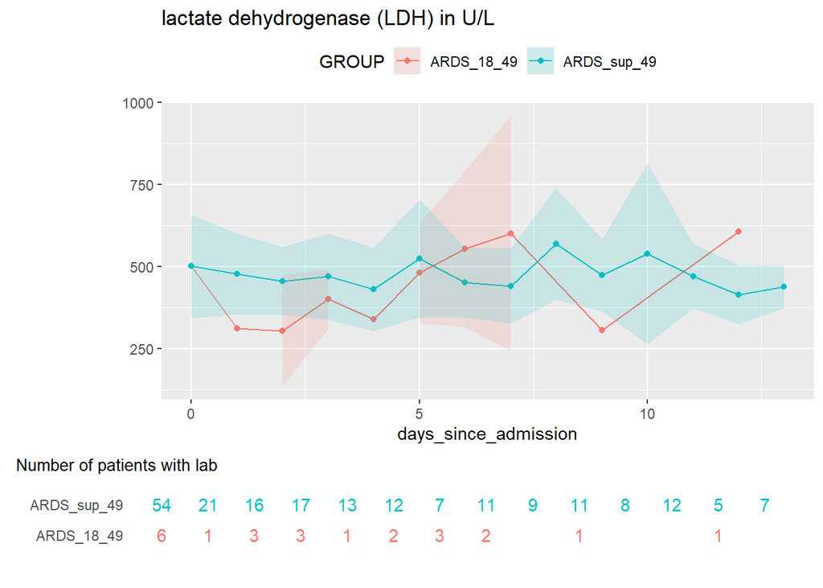

[8 more figures not shown]

[output not shown]

[output cut: 64 more lines]

[output not shown]

# 6 Descriptive analysis

## 6.1 Demographics

**Age group**

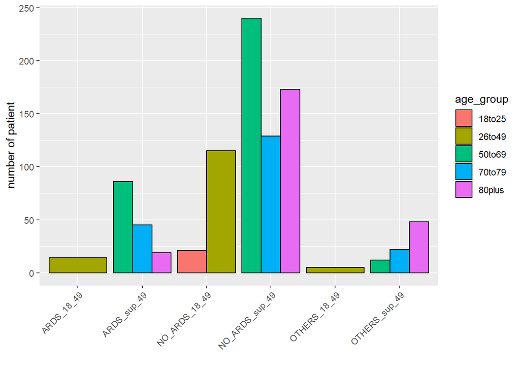

**Sex group**

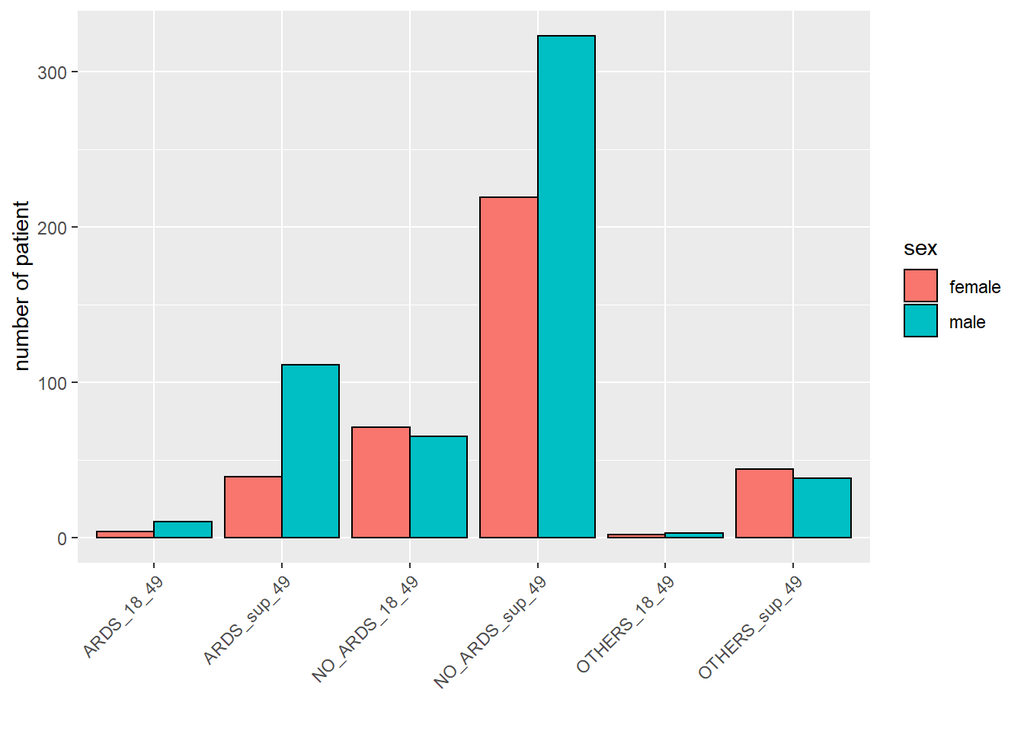

## 6.2 Hospitalization

**Previous hospitalization in the year before:** **Number of Patients with and without ICD-10 in the year before**

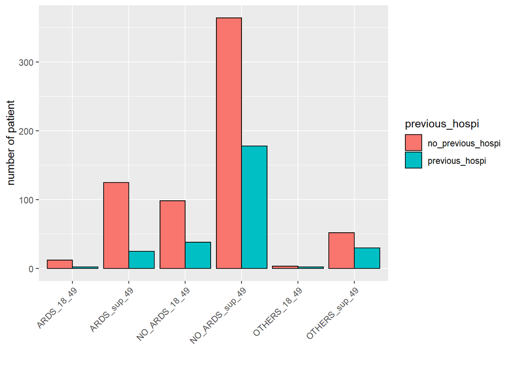

**Patients with and without rehopitalization after Covid admission**

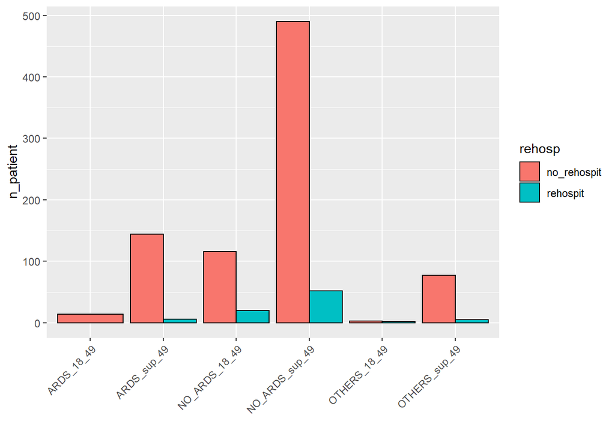

## 6.3 ICD-10/9

### 6.3.1 ICD10/9-Before hospitalization due to covid

**Number of patients with ICD10/9 per groups**

| ICD | ICD_title | NO_ARDS_sup_49 | ARDS_sup_49 | NO_ARDS_18_49 | OTHERS_18_49 | OTHERS_sup_49 | ARDS_18_49 |
| --- | --- | --- | --- | --- | --- | --- | --- |
| A04 | Other bacterial intestinal infections | 1 |  |  |  |  |  |
| A09 | Infectious gastroenteritis and colitis, unspecified | 20 | 2 | 3 | 1 | 1 |  |
| A15 | Respiratory tuberculosis | 1 |  |  |  | 1 |  |
| A18 | Tuberculosis of other organs | 1 |  |  |  |  |  |
| A31 | Infection due to other mycobacteria | 1 |  |  |  |  |  |
| A40 | Streptococcal sepsis | 1 |  | 2 |  |  |  |
| A41 | Other sepsis | 9 | 1 | 2 |  |  |  |
| A46 | Erysipelas | 1 |  | 2 |  | 2 |  |
| A52 | Late syphilis | 1 |  |  |  |  |  |
| A53 | Other and unspecified syphilis |  |  | 1 |  |  |  |

[output cut: 690 more lines]

**Percentage of patients with ICD10 code**

| ICD | ICD_title | NO_ARDS_sup_49 | ARDS_sup_49 | NO_ARDS_18_49 | OTHERS_18_49 | OTHERS_sup_49 | ARDS_18_49 |
| --- | --- | --- | --- | --- | --- | --- | --- |
| A04 | Other bacterial intestinal infections | 0.2 |  |  |  |  |  |
| A09 | Infectious gastroenteritis and colitis, unspecified | 3.7 | 1.3 | 2.2 | 20 | 1.2 |  |
| A15 | Respiratory tuberculosis | 0.2 |  |  |  | 1.2 |  |
| A18 | Tuberculosis of other organs | 0.2 |  |  |  |  |  |
| A31 | Infection due to other mycobacteria | 0.2 |  |  |  |  |  |
| A40 | Streptococcal sepsis | 0.2 |  | 1.5 |  |  |  |
| A41 | Other sepsis | 1.7 | 0.7 | 1.5 |  |  |  |
| A46 | Erysipelas | 0.2 |  | 1.5 |  | 2.4 |  |
| A52 | Late syphilis | 0.2 |  |  |  |  |  |
| A53 | Other and unspecified syphilis |  |  | 0.7 |  |  |  |

[output cut: 690 more lines]

### 6.3.2 After hospitalization due to covid

**Number of patients with ICD10**

| ICD | ICD_title | NO_ARDS_18_49 | ARDS_sup_49 | NO_ARDS_sup_49 | OTHERS_sup_49 | ARDS_18_49 | OTHERS_18_49 |
| --- | --- | --- | --- | --- | --- | --- | --- |
| A02 | Other salmonella infections | 1 |  |  |  |  |  |
| A04 | Other bacterial intestinal infections |  | 2 | 4 | 1 |  |  |
| A08 | Viral and other specified intestinal infections |  | 1 | 2 |  |  |  |
| A09 | Infectious gastroenteritis and colitis, unspecified | 12 | 25 | 114 | 16 | 5 | 1 |
| A16 |  |  |  | 1 |  |  |  |
| A18 | Tuberculosis of other organs |  |  | 1 |  |  |  |
| A31 | Infection due to other mycobacteria |  |  | 1 |  |  |  |
| A40 | Streptococcal sepsis |  | 1 | 3 | 1 |  |  |
| A41 | Other sepsis | 1 | 25 | 17 | 6 | 3 |  |
| A46 | Erysipelas | 1 |  |  |  |  |  |

[output cut: 801 more lines]

**Percentage of patients with ICD10**

| ICD | ICD_title | NO_ARDS_18_49 | ARDS_sup_49 | NO_ARDS_sup_49 | OTHERS_sup_49 | ARDS_18_49 | OTHERS_18_49 |
| --- | --- | --- | --- | --- | --- | --- | --- |
| A02 | Other salmonella infections | 0.7 |  |  |  |  |  |
| A04 | Other bacterial intestinal infections |  | 1.3 | 0.7 | 1.2 |  |  |
| A08 | Viral and other specified intestinal infections |  | 0.7 | 0.4 |  |  |  |
| A09 | Infectious gastroenteritis and colitis, unspecified | 8.8 | 16.7 | 21 | 19.5 | 35.7 | 20 |
| A16 |  |  |  | 0.2 |  |  |  |
| A18 | Tuberculosis of other organs |  |  | 0.2 |  |  |  |
| A31 | Infection due to other mycobacteria |  |  | 0.2 |  |  |  |
| A40 | Streptococcal sepsis |  | 0.7 | 0.6 | 1.2 |  |  |
| A41 | Other sepsis | 0.7 | 16.7 | 3.1 | 7.3 | 21.4 |  |
| A46 | Erysipelas | 0.7 |  |  |  |  |  |

[output cut: 801 more lines]

## 6.4 Pheno-10

**Number of patients with ICD10 after hospitalization due to covid**

| PheCode | Phenotype | ARDS_18_49 | ARDS_sup_49 | NO_ARDS_18_49 | NO_ARDS_sup_49 | OTHERS_18_49 | OTHERS_sup_49 |
| --- | --- | --- | --- | --- | --- | --- | --- |
| 8 | Intestinal infection | 5 | 25 | 12 | 114 | 1 | 16 |
| 8.5 | Bacterial enteritis |  |  | 1 |  |  |  |
| 8.6 | Viral Enteritis |  | 1 |  | 2 |  |  |
| 10 | Tuberculosis |  |  |  | 2 |  |  |
| 38.1 | Gram negative septicemia |  | 1 |  | 3 |  | 1 |
| 41 | Bacterial infection NOS |  | 1 |  | 1 |  |  |
| 53 | Herpes zoster | 1 |  |  |  |  |  |
| 54 | Herpes simplex | 1 | 7 |  | 3 |  | 1 |
| 70 | Viral hepatitis |  |  | 3 | 3 |  | 1 |
| 70.2 | Viral hepatitis B |  |  | 1 |  |  |  |

[output cut: 435 more lines]

## 6.5 Medication

**Number of patient with at least one prescription per medication class**

| concept_code | ARDS_18_49 | ARDS_sup_49 | NO_ARDS_18_49 | NO_ARDS_sup_49 | OTHERS_18_49 | OTHERS_sup_49 |
| --- | --- | --- | --- | --- | --- | --- |
| ACEI | 1 | 15 | 5 | 59 | 1 | 6 |
| ARB | 3 | 21 | 7 | 85 | 1 | 6 |
| COAGB | 11 | 110 | 89 | 456 | 3 | 69 |
| DIURETIC | 1 | 13 | 4 | 107 | 1 | 29 |
| COAGA |  | 5 | 1 | 24 |  | 4 |
| COVIDVIRAL |  | 2 | 9 | 42 |  | 3 |
| HCQ |  | 2 | 3 | 13 |  | 1 |
| ILI |  | 3 | 1 | 9 |  | 2 |
| SIANES |  | 6 |  |  | 1 | 61 |
| INTERFERON |  |  | 1 |  |  |  |

[output cut: 1 more lines]

## 6.6 Procedure

**Number of patient with at least one procedure per procedure**

| concept_code | title | ARDS_18_49 | ARDS_sup_49 | NO_ARDS_18_49 | NO_ARDS_sup_49 | OTHERS_18_49 | OTHERS_sup_49 |
| --- | --- | --- | --- | --- | --- | --- | --- |
| 0BH17EZ | Insertion of Endotracheal Airway into Trachea, Via Opening | 5 | 51 |  |  |  | 11 |
| 5A09357 | Assistance with Respiratory Ventilation, Less than 24 Consecutive Hours, Continuous Positive Airway Pressure | 8 | 70 |  |  | 3 | 12 |
| 5A0935B | Assistance with Respiratory Ventilation, Less than 24 Consecutive Hours, Intermittent Negative Airway Pressure | 11 | 95 |  |  | 2 | 18 |
| 5A0935Z | Assistance with Respiratory Ventilation, Less than 24 Consecutive Hours |  | 13 |  |  |  | 8 |

## 6.7 Outcomes

| GROUP | # patients | # dead patients | # dead patients before 28 days | # dead patients before 90 days | # patients discharged before 28 days | # patients discharged before 90 days |
| --- | --- | --- | --- | --- | --- | --- |
| ARDS_18_49 | 14 | 0 | 0 | 0 | 5 | 13 |
| ARDS_sup_49 | 150 | 37 | 30 | 36 | 102 | 138 |
| NO_ARDS_18_49 | 136 | 0 | 0 | 0 | 133 | 136 |
| NO_ARDS_sup_49 | 542 | 46 | 40 | 46 | 493 | 540 |
| OTHERS_18_49 | 5 | 2 | 1 | 2 | 4 | 5 |
| OTHERS_sup_49 | 82 | 50 | 43 | 48 | 64 | 80 |